# NBA Career Comparison: Grant Hill vs. Penny Hardaway

## Introduction

Grant Hill and Penny Hardaway represent two of the NBA's most tantalizing "what if" stories. Both players emerged in the mid-1990s as transcendent talents who seemed destined for all-time greatness before injuries dramatically altered their career trajectories. This analysis provides a comprehensive comparison of their NBA careers, examining their statistics, achievements, team success, and lasting impact on the game.

Both players entered the league with tremendous fanfare - Hill as the 3rd overall pick in 1994 out of Duke University, and Hardaway as the 3rd overall pick in 1993 from Memphis State (now University of Memphis). Their early careers showcased remarkable versatility, athleticism, and basketball IQ that drew comparisons to legends like Magic Johnson. However, their paths would diverge significantly as injuries took their toll, creating one of basketball's most compelling parallel narratives of unfulfilled potential.

This analysis will examine their careers from multiple angles, using statistical analysis and data visualization to determine who had the better career during their peak years and overall. We'll explore not just what they accomplished, but also what might have been had their bodies cooperated with their immense talents.

## Data Collection and Preparation

For this analysis, we collected comprehensive data on both players' careers using the NBA API. This includes regular season statistics, awards and accolades, and player information. We also gathered information about their playoff performances, team success, and the impact of injuries on their careers through additional research.

The data collection process involved:

1. Retrieving career statistics from the NBA API
2. Collecting awards and accolades information
3. Researching injury history and impact
4. Gathering team success metrics during their tenures

Let's first load the data we've collected:

```
Grant Hill Career Seasons: 18
Penny Hardaway Career Seasons: 16
Grant Hill Awards: 29
Penny Hardaway Awards: 14
```

## Career Statistics Comparison

Both Grant Hill and Penny Hardaway showcased exceptional skills during their NBA careers. Let's examine their career statistics to understand their playing styles, strengths, and overall impact on the court.

Grant Hill was known for his all-around game, combining scoring, rebounding, and playmaking abilities. As a 6'8" forward with point guard skills, he regularly filled the stat sheet and was one of the league's premier triple-double threats during his prime years with the Detroit Pistons. His career was marked by remarkable efficiency and versatility before ankle injuries derailed his trajectory.

Penny Hardaway, at 6'7", revolutionized the point guard position with his size, court vision, and scoring ability. Paired with Shaquille O'Neal in Orlando, Hardaway created one of the NBA's most dynamic duos of the mid-1990s. His combination of playmaking and scoring made him nearly unstoppable before knee injuries significantly diminished his athleticism and effectiveness.

Let's visualize their career trajectories in terms of points and assists:

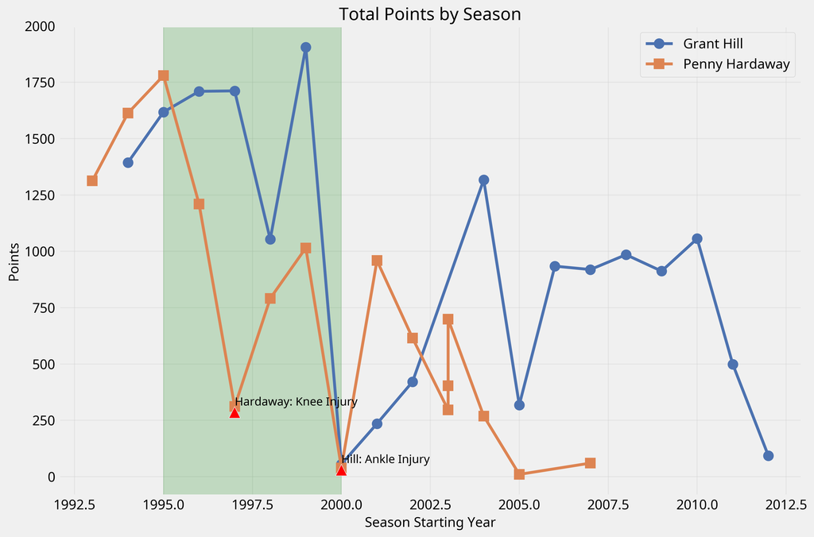

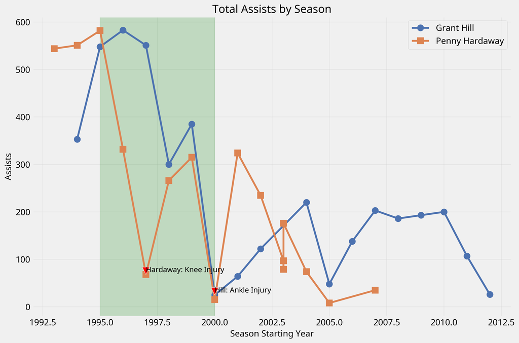

Penny Hardaway's decline began earlier, with knee problems starting in the 1997-98 season. His production never returned to the elite levels of his first four seasons, though he remained in the league for 14 seasons total. The sharp drop-off in both points and assists underscores how dramatically injuries affected his game, which relied heavily on athleticism and explosiveness.

Now, let's examine their career averages across key statistical categories:

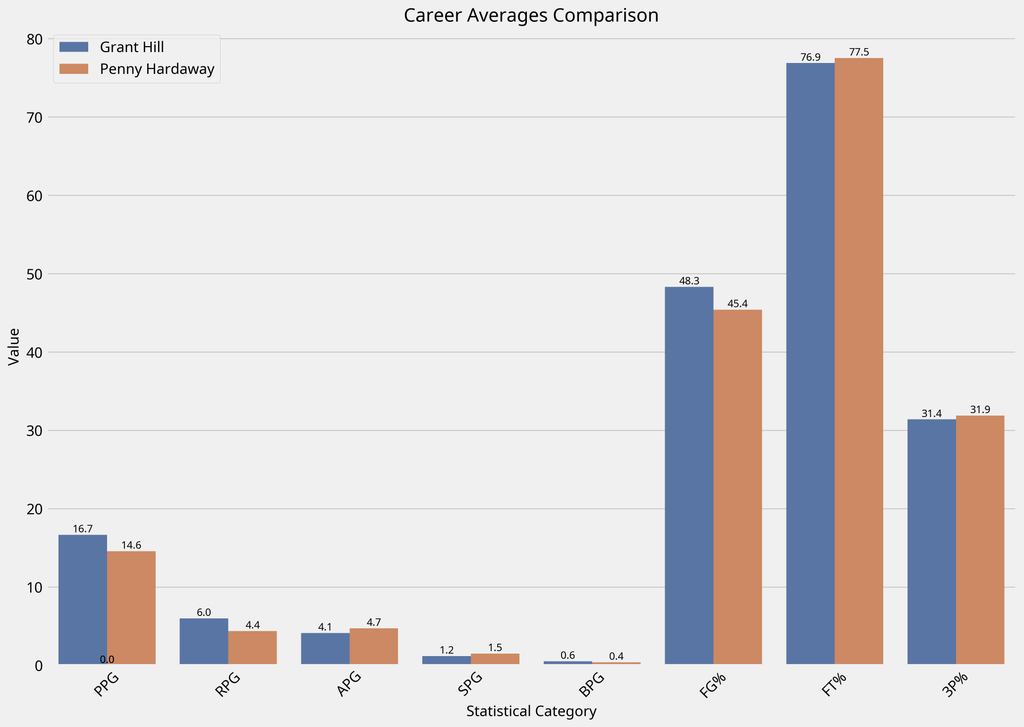

However, career averages don't tell the complete story, especially for players whose careers were dramatically altered by injuries. To better understand their impact at their best, we need to examine their peak years specifically.

## Peak Years Analysis

For Grant Hill, we've identified his peak years as the 1995-96 through 1999-00 seasons with the Detroit Pistons. During this five-year stretch, Hill was one of the NBA's elite players, earning All-NBA honors each season and establishing himself as one of the league's most complete players.

For Penny Hardaway, his peak years were shorter but equally impressive, spanning from 1994-95 through 1996-97 with the Orlando Magic. During these three seasons, Hardaway made the All-NBA First Team twice and led the Magic to the NBA Finals in 1995.

Let's compare their statistical production during these peak periods:

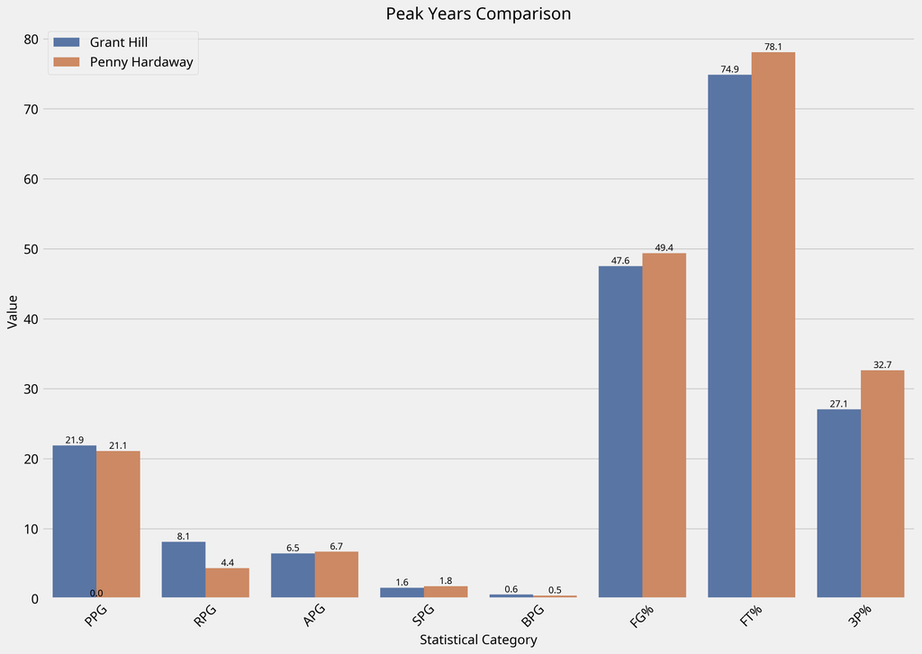

During their respective peak years, both players were remarkably productive. Grant Hill averaged 21.92 PPG, 8.14 RPG, and 6.48 APG, showcasing his all-around excellence. His rebounding numbers in particular stand out, as they were exceptional for a player who often functioned as a point forward.

Penny Hardaway averaged 21.11 PPG, 4.37 RPG, and 6.72 APG during his peak, with superior shooting efficiency. His field goal percentage (49.39%) and three-point percentage (32.67%) were both higher than Hill's during their respective peaks, highlighting Hardaway's scoring efficiency.

To better understand how their skills compared during their overlapping prime years, let's examine a radar chart comparing their 1996-97 season, when both were at or near their peaks:

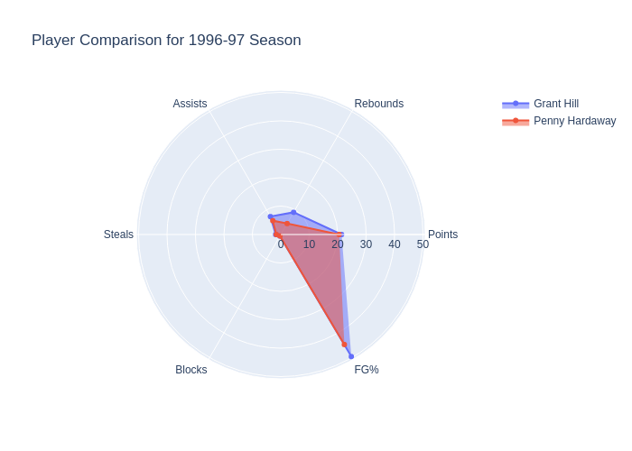

This visualization reinforces that both players were exceptional all-around talents with slightly different skill emphases based on their positions and team roles.

## Achievements and Accolades

Beyond statistics, awards and accolades provide important context for evaluating NBA careers. Let's examine how Grant Hill and Penny Hardaway compare in terms of individual recognition and honors:

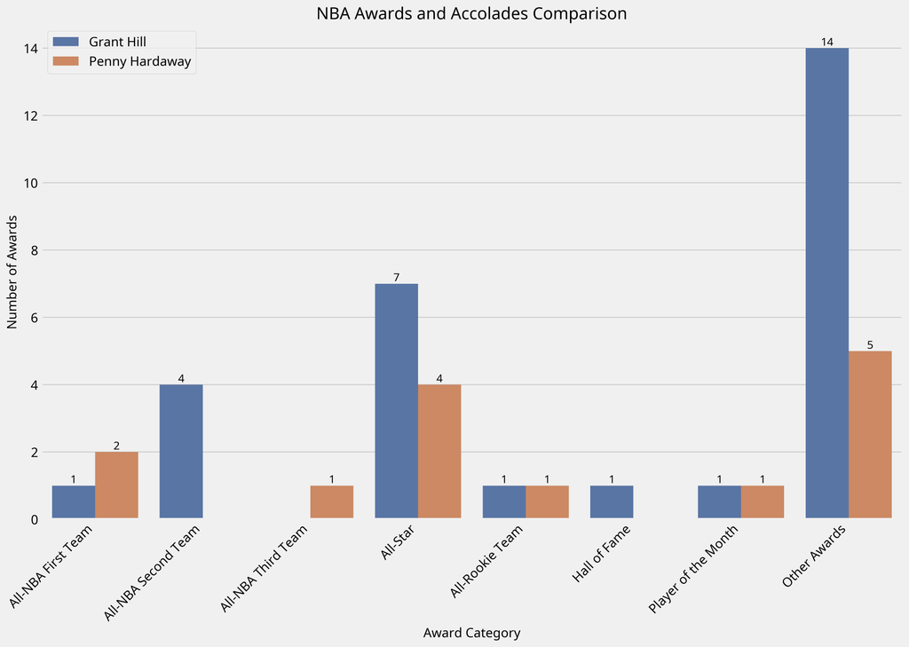

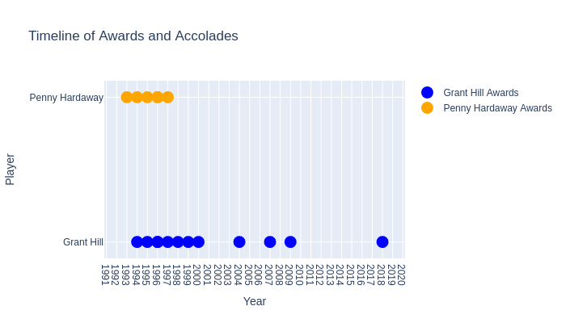

The awards comparison reveals several key differences in their career recognition. Grant Hill accumulated more total accolades, including 7 All-Star selections compared to Hardaway's 4, and 5 All-NBA selections to Hardaway's 3. Hill was also inducted into the Basketball Hall of Fame in 2018, an honor that has eluded Hardaway thus far.

However, Penny Hardaway achieved higher peak recognition in some respects, making the All-NBA First Team twice (1994-95 and 1995-96), while Hill made it once (1996-97). This suggests that at his absolute peak, Hardaway may have been considered among the very elite of the NBA, even if for a shorter period than Hill.

The awards timeline visualization shows how their recognition overlapped in the mid-1990s before injuries began to impact their careers. Both players received significant accolades early in their careers, with Hardaway's recognition concentrated in a shorter timeframe while Hill's was spread across more seasons.

Let's examine their complete achievements in more detail:

### Grant Hill Achievements:

- 7-time NBA All-Star (1995-1998, 2000, 2001, 2005)
- 5-time All-NBA selection
  - First Team: 1996-97
  - Second Team: 1995-96, 1997-98, 1998-99, 1999-00
- NBA All-Rookie First Team (1994-95)
- Co-Rookie of the Year (1994-95, shared with Jason Kidd)
- Olympic Gold Medal (1996)
- Naismith Memorial Basketball Hall of Fame (Class of 2018)
- Led NBA in triple-doubles (1996-97)
- NCAA Champion (1991, 1992 with Duke)

### Penny Hardaway Achievements:

- 4-time NBA All-Star (1995-1998)
- 3-time All-NBA selection
  - First Team: 1994-95, 1995-96
  - Third Team: 1996-97
- NBA All-Rookie First Team (1993-94)
- Olympic Gold Medal (1996)
- Led Orlando Magic to NBA Finals (1995)
- Iconic Nike 'Lil Penny' marketing campaign

While Hill accumulated more individual accolades over his longer effective career, Hardaway reached greater team success by leading the Orlando Magic to the NBA Finals in 1995. This represents a significant achievement that Hill never matched, as his teams never advanced beyond the first round of the playoffs during his prime years.

## Team Success and Playoff Performance

Individual statistics and accolades tell only part of the story. Basketball is ultimately a team sport, and a player's impact is often measured by team success. Let's examine how Grant Hill and Penny Hardaway's teams performed during their careers:

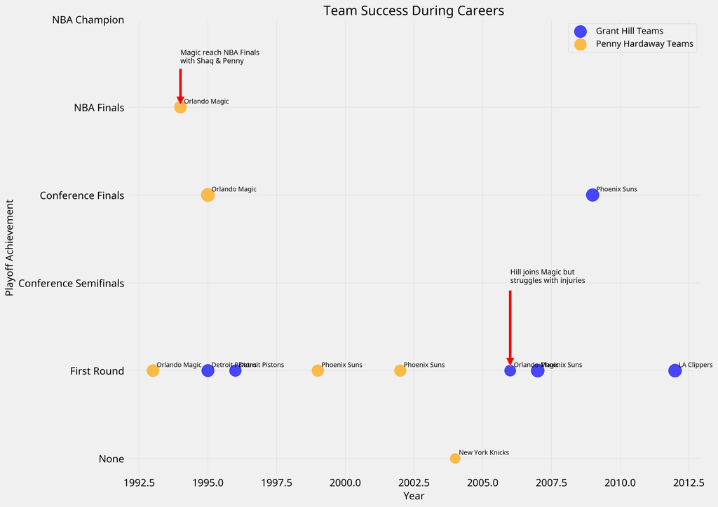

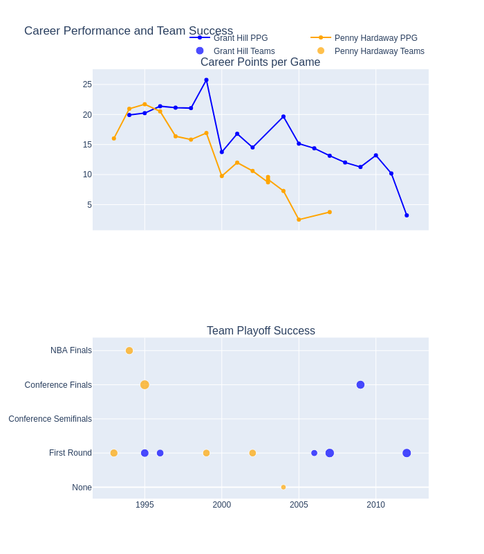

The team success visualizations reveal a significant advantage for Penny Hardaway in terms of playoff achievement. While with the Orlando Magic, Hardaway reached the NBA Finals in 1995 and the Eastern Conference Finals in 1996, representing the deepest playoff runs for either player. Grant Hill's teams never advanced beyond the first round during his prime years with the Detroit Pistons, though he was part of more successful teams later in his career with the Phoenix Suns, including a Western Conference Finals appearance in 2010 when he was a role player.

The combined visualization of career performance and team success illustrates how their individual production aligned with their teams' achievements. Hardaway's peak individual years coincided with Orlando's greatest team success, while Hill's excellent individual statistics with Detroit didn't translate to deep playoff runs.

This difference in team success provides important context for evaluating their careers. While Hill may have accumulated more individual accolades, Hardaway experienced greater team achievement during his prime, suggesting he may have had a more significant impact on winning at his peak.

### Team Success Comparison:

**Penny Hardaway:**

## Injury Impact Analysis

No analysis of Grant Hill and Penny Hardaway would be complete without examining the profound impact injuries had on their careers. Both players saw their trajectories dramatically altered by injuries that prevented them from fulfilling their immense potential.

**Grant Hill's Injury Saga:**

Hill's career was forever changed by an ankle injury suffered near the end of the 1999-2000 season. Initially diagnosed as a sprain, Hill played through the injury in the playoffs, unknowingly causing further damage. After signing with the Orlando Magic in the offseason, it was discovered that he had a broken ankle that required surgery. This began a nightmare sequence of complications, infections, and additional surgeries that nearly ended his career.

Hill missed nearly all of his first four seasons with Orlando, playing only 47 games total during that span. The timing was particularly cruel, as he was entering what should have been the prime of his career at age 28. While he eventually returned to become a productive player and even made an All-Star team in 2005, he never regained the elite form that had made him one of the NBA's best players.

**Penny Hardaway's Injury Struggles:**

Hardaway's decline began earlier in his career, with knee problems emerging during the 1997-98 season. He underwent the first of what would be multiple knee surgeries, missing most of that season. Unlike Hill, who had several completely healthy seasons before his injury, Hardaway's prime was cut short after just four seasons.

The timing of Hardaway's injuries coincided with Shaquille O'Neal's departure from Orlando to the Los Angeles Lakers, placing even more pressure on Hardaway to carry the team. His explosiveness and athleticism, which were central to his playing style, never fully returned after the knee surgeries. While he remained in the league for a decade after his initial injuries, he was never again selected as an All-Star or to an All-NBA team.

The contrast in their post-injury careers is notable. Hill managed to adapt his game and remain effective, while Hardaway struggled to find a new identity as his athleticism diminished. This difference may be partly attributed to their playing styles - Hill's game was less dependent on pure athleticism than Hardaway's - and partly to the nature of their injuries, with knee injuries often being more limiting for basketball players than ankle injuries in the long term.

## Legacy and Cultural Impact

Beyond statistics and achievements, both Grant Hill and Penny Hardaway left significant legacies on basketball and popular culture.

**Grant Hill's Legacy:**

Hill entered the NBA as one of its most marketable young stars, signing major endorsement deals with companies like Fila and Sprite. He was positioned as one of the potential heirs to Michael Jordan's throne as the face of the NBA, along with players like Penny Hardaway and Kobe Bryant. His clean-cut image, Duke pedigree, and all-around game made him appealing to a wide audience.

Beyond his playing career, Hill has built an impressive post-basketball resume. He became a respected broadcaster, a part-owner of the Atlanta Hawks, and eventually the Managing Director of the USA Basketball Men's National Team. His induction into the Basketball Hall of Fame in 2018 cemented his place in basketball history, recognizing both his peak years and his remarkable perseverance through injuries.

Hill is often cited as an example of grace and professionalism in sports, maintaining a positive attitude through devastating setbacks. His story is one of adaptation and resilience, showing how an elite athlete can reinvent himself when his body no longer allows him to play at his previous level.

**Penny Hardaway's Legacy:**

Hardaway's cultural impact was perhaps even greater than Hill's during their playing days, largely due to Nike's iconic "Lil Penny" marketing campaign. The Chris Rock-voiced puppet alter ego became a pop culture phenomenon, with commercials that are still remembered fondly today. Hardaway's signature shoes remain popular retro releases, speaking to his enduring appeal.

As a player, Hardaway helped revolutionize the point guard position with his size and versatility. At 6'7", he was a precursor to the modern trend of bigger playmakers like Luka Dončić and Ben Simmons. His flashy yet efficient style made him one of the league's most exciting players to watch during his prime.

After his playing career, Hardaway returned to his hometown of Memphis to coach high school basketball before becoming the head coach at his alma mater, the University of Memphis. This connection to his roots and commitment to developing young players has added another dimension to his basketball legacy.

Both players are frequently mentioned in discussions of the NBA's greatest "what if" scenarios, with fans and analysts speculating about what they might have accomplished had they remained healthy. Their legacies are defined not just by what they achieved, but by the tantalizing glimpses of greatness that suggested even more might have been possible.

## Conclusion: Who Had the Better Career?

After comprehensive analysis of their statistics, achievements, team success, and legacies, we can draw several conclusions about the NBA careers of Grant Hill and Penny Hardaway.

**Peak Performance:**

At their absolute peaks, both players were among the NBA's elite. Hardaway's best seasons (1994-95 and 1995-96) featured back-to-back All-NBA First Team selections and an NBA Finals appearance, suggesting that his short-term peak might have been slightly higher than Hill's. However, Hill maintained his elite level for a longer period, earning five consecutive All-NBA selections from 1996 to 2000.

**Statistical Production:**

Statistically, their peak years were remarkably similar in scoring (Hill: 21.92 PPG, Hardaway: 21.11 PPG) and assists (Hill: 6.48 APG, Hardaway: 6.72 APG), with Hill holding a significant advantage in rebounding (8.14 RPG vs. 4.37 RPG). Hardaway was the more efficient shooter, while Hill got to the free throw line more frequently.

**Team Success:**

Hardaway holds a clear advantage in team achievement, having led the Orlando Magic to the NBA Finals in 1995 and the Eastern Conference Finals in 1996. Hill's teams never advanced beyond the first round during his prime years, though he was part of more successful teams later in his career as a role player.

**Longevity and Resilience:**

**Accolades and Recognition:**

Hill accumulated more total accolades, including more All-Star selections (7 vs. 4) and All-NBA selections (5 vs. 3). His induction into the Basketball Hall of Fame represents significant recognition that Hardaway has not yet received. However, Hardaway's two All-NBA First Team selections (compared to Hill's one) suggest higher peak recognition.

**Final Assessment:**

The question of who had the better NBA career depends on how one weighs different aspects of their careers:

- If valuing peak performance and team success most highly, Penny Hardaway's case is strong, with his NBA Finals appearance and consecutive All-NBA First Team selections.
- If prioritizing sustained excellence, career accolades, and longevity, Grant Hill holds the advantage with his longer period of elite play, more total accolades, and Hall of Fame induction.

Both players represent fascinating "what if" scenarios in NBA history. Hardaway's career arc suggests he might have been one of the all-time great guards had he remained healthy, while Hill was on a trajectory that had him mentioned alongside legends like Larry Bird and Magic Johnson before his injuries.

In the final analysis, Grant Hill's career must be considered more accomplished based on his longer period of elite play, greater accumulation of accolades, remarkable longevity despite injuries, and Hall of Fame induction. However, Penny Hardaway's higher team achievement and arguably higher short-term peak make this a closer comparison than their respective post-career recognition might suggest.

Both players left indelible marks on basketball history and continue to be remembered not just for what they accomplished, but for what their transcendent talents suggested might have been possible in alternate, injury-free universes.